# The Salary question?

6/6/2020

“This data set consists of Placement data of students in B-School. It includes secondary and higher secondary school percentage and specialization. It also includes degree specialization, type and Work experience and salary offered to the placed students.”

Source: Kaggle (https://www.kaggle.com/benroshan/factors-affecting-campus-placement)

I attempted to answer the following questions from the dataset:

Q. How is salary correlated with given variables?

Q. How are the variables related with the amount of salaries offered during placement?

Q. Can the salaries be predicted based on the related variables?

Q. How can this student cohort be categorized based on their distinct standing on different variables in the dataset?

```r
library(tidyverse)
place_data <- read.csv("Placement_Data_Full_Class.csv")
```

*Exploratory Data Analysis*

```r
#A snashpshot of data helps understand how the data is placed.
head(place_data)
```

```
##   sl_no gender ssc_p   ssc_b hsc_p   hsc_b    hsc_s degree_p  degree_t workex
## 1     1      M 67.00  Others 91.00  Others Commerce    58.00  Sci&Tech     No
## 2     2      M 79.33 Central 78.33  Others  Science    77.48  Sci&Tech    Yes
## 3     3      M 65.00 Central 68.00 Central     Arts    64.00 Comm&Mgmt     No
## 4     4      M 56.00 Central 52.00 Central  Science    52.00  Sci&Tech     No
## 5     5      M 85.80 Central 73.60 Central Commerce    73.30 Comm&Mgmt     No
## 6     6      M 55.00  Others 49.80  Others  Science    67.25  Sci&Tech    Yes
##   etest_p specialisation mba_p     status salary
## 1    55.0         Mkt&HR 58.80     Placed 270000
## 2    86.5        Mkt&Fin 66.28     Placed 200000
## 3    75.0        Mkt&Fin 57.80     Placed 250000
## 4    66.0         Mkt&HR 59.43 Not Placed     NA
## 5    96.8        Mkt&Fin 55.50     Placed 425000
## 6    55.0        Mkt&Fin 51.58 Not Placed     NA
```

```r
#There's a mix of factors and integers in this dataset. Salary column shows NAs for people who have not been placed yet. For this analysis, those rows will be removed.
str(place_data)
```

```
## 'data.frame':    215 obs. of  15 variables:
##  $ sl_no         : int  1 2 3 4 5 6 7 8 9 10 ...
##  $ gender        : Factor w/ 2 levels "F","M": 2 2 2 2 2 2 1 2 2 2 ...
##  $ ssc_p         : num  67 79.3 65 56 85.8 ...
##  $ ssc_b         : Factor w/ 2 levels "Central","Others": 2 1 1 1 1 2 2 1 1 1 ...
##  $ hsc_p         : num  91 78.3 68 52 73.6 ...
##  $ hsc_b         : Factor w/ 2 levels "Central","Others": 2 2 1 1 1 2 2 1 1 1 ...
##  $ hsc_s         : Factor w/ 3 levels "Arts","Commerce",..: 2 3 1 3 2 3 2 3 2 2 ...
##  $ degree_p      : num  58 77.5 64 52 73.3 ...
##  $ degree_t      : Factor w/ 3 levels "Comm&Mgmt","Others",..: 3 3 1 3 1 3 1 3 1 1 ...
##  $ workex        : Factor w/ 2 levels "No","Yes": 1 2 1 1 1 2 1 2 1 1 ...
##  $ etest_p       : num  55 86.5 75 66 96.8 ...
##  $ specialisation: Factor w/ 2 levels "Mkt&Fin","Mkt&HR": 2 1 1 2 1 1 1 1 1 1 ...
##  $ mba_p         : num  58.8 66.3 57.8 59.4 55.5 ...
##  $ status        : Factor w/ 2 levels "Not Placed","Placed": 2 2 2 1 2 1 1 2 2 1 ...
##  $ salary        : int  270000 200000 250000 NA 425000 NA NA 252000 231000 NA ...
```

```r
place_data <- na.omit(place_data)
```

```r
summary(place_data)
```

```
##      sl_no        gender      ssc_p           ssc_b        hsc_p
##  Min.   :  1.00   F: 48   Min.   :49.00   Central:78   Min.   :50.83
##  1st Qu.: 57.75   M:100   1st Qu.:65.00   Others :70   1st Qu.:63.00
##  Median :108.50           Median :72.50                Median :68.00
##  Mean   :106.88           Mean   :71.72                Mean   :69.93
##  3rd Qu.:153.25           3rd Qu.:78.12                3rd Qu.:75.25
##  Max.   :214.00           Max.   :89.40                Max.   :97.70
##      hsc_b         hsc_s       degree_p          degree_t   workex
##  Central:57   Arts    : 6   Min.   :56.00   Comm&Mgmt:102   No :84
##  Others :91   Commerce:79   1st Qu.:65.00   Others   :  5   Yes:64
##               Science :63   Median :68.00   Sci&Tech : 41
##                             Mean   :68.74
##                             3rd Qu.:72.42
##                             Max.   :91.00
##     etest_p      specialisation     mba_p              status
##  Min.   :50.00   Mkt&Fin:95     Min.   :52.38   Not Placed:  0
##  1st Qu.:60.00   Mkt&HR :53     1st Qu.:57.77   Placed    :148
##  Median :72.00                  Median :62.24
##  Mean   :73.24                  Mean   :62.58
##  3rd Qu.:85.00                  3rd Qu.:66.76
##  Max.   :98.00                  Max.   :77.89
##      salary
##  Min.   :200000
##  1st Qu.:240000
##  Median :265000
##  Mean   :288655
##  3rd Qu.:300000
##  Max.   :940000
```

```r
attach(place_data)
```

Exploring the response variable - Salary

```r
#The standard deviation for salaries is high, 93,457, which means that salaries have a large amount of variation. This could be due to maybe score difference at different level, roles being offered, or gender maybe.
sd(salary)
```

```
## [1] 93457.45
```

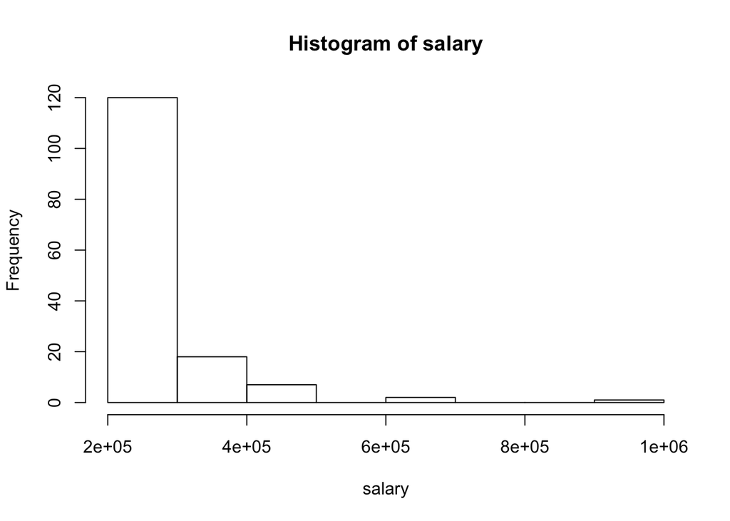

```r
#But bulk of the students are offered salaries in the 200,000 to 300,000 range. And very few have been offered salaries beyond this range.
hist(salary)
```

```r
#There's a merit in seeing actual share of students, even number of students for the higher salaries. Since, it's a tiny dataset, an outlier can have a larger effect on any results.

table(salary)
```

```
## salary
## 200000 204000 210000 216000 218000 220000 225000 230000 231000 233000 236000
##      6      2      4      3      2      5      1      2      1      1      2
## 240000 250000 252000 255000 260000 264000 265000 268000 270000 275000 276000
##     15     18      2      1      7      1      6      1      4      5      2
## 278000 280000 285000 287000 290000 295000 300000 320000 336000 340000 350000
##      1      2      1      1      1      1     22      1      1      1      3
## 360000 380000 393000 400000 411000 420000 425000 450000 500000 650000 690000
##      6      1      1      4      1      1      1      1      3      1      1
## 940000
##      1
```

```r
#It's a smaller dataset, so there's an advantage of looking directly at the numbers, in larger dataset, proportion of salaries in a range would have made more sense.

#Clearly, of 148 students, only 28 students over 300,000
nrow(subset(place_data %>% filter(salary > 300000)))
```

```
## [1] 28
```

```r
#and,

#only 6 students were offered salaries equal to and above 500,000.
nrow(subset(place_data %>% filter(salary >= 500000)))
```

```
## [1] 6
```

```r
#Removing these 6 rows would reduce the variation in the values, as the gap between the salary range is also much wider from rest of the salary range. Removing this range result in a better fit in the regression model in the forthcoming steps.
```

```r
#Deleted six rows >= 500,000
data_minus6 <- place_data %>% filter(salary <500000)
```

Q1. How is salary correlated with given variables?

```r
#List of numerical variables from the main dataset
data_int <- data_minus6[,c(3,5,8,11,13,15)]

#Correlation between salary and other variables is not very noticeable, though all of them are positively correlated.
cor(data_int)
```

```
##              ssc_p     hsc_p   degree_p   etest_p     mba_p     salary
## ssc_p    1.0000000 0.3157858 0.37824470 0.3299733 0.4412433 0.22121734
## hsc_p    0.3157858 1.0000000 0.18312895 0.2631095 0.3393129 0.11855446
## degree_p 0.3782447 0.1831290 1.00000000 0.1978888 0.4991666 0.09306529
## etest_p  0.3299733 0.2631095 0.19788883 1.0000000 0.2776463 0.29918118
## mba_p    0.4412433 0.3393129 0.49916655 0.2776463 1.0000000 0.21932440
## salary   0.2212173 0.1185545 0.09306529 0.2991812 0.2193244 1.00000000
```

```r
#correlation between categorical variables and Salary?
```

Q.2 How are the variables related with the amount of salaries offered during placement?

```r
#A multiple regression model should be able to help in explaining the variation in salary due to the given explanatory variables in the model.
library(car)
attach(data_minus6)
#removing "serial_no" and "status" columns as they don't serve any purpose.
data_minus6 <- data_minus6[,-c(1,14)]
```

Q. How are the variables related with the amount of salaries offered during placement?

```r
#*Multiple Regression Model*

model_salary <- lm(salary~., data = data_minus6)

summary(model_salary)
```

```
##
## Call:
## lm(formula = salary ~ ., data = data_minus6)
##
## Residuals:
##     Min      1Q  Median      3Q     Max
## -113376  -33285   -7587   21301  128327
##
## Coefficients:
##                      Estimate Std. Error t value Pr(>|t|)
## (Intercept)           52590.4    64200.7   0.819  0.41423
## genderM               26831.8    10047.3   2.671  0.00856 **
## ssc_p                   737.5      630.0   1.171  0.24395
## ssc_bOthers           -1200.7    12144.5  -0.099  0.92140
## hsc_p                  -465.0      592.8  -0.784  0.43428
## hsc_bOthers            2339.1    11914.0   0.196  0.84467
## hsc_sCommerce         26607.7    24252.5   1.097  0.27467
## hsc_sScience           6573.8    26139.1   0.251  0.80184
## degree_p               -343.4      802.9  -0.428  0.66959
## degree_tOthers        38796.3    26550.4   1.461  0.14642
## degree_tSci&Tech      25351.5    14095.7   1.799  0.07447 .
## workexYes            -12324.8     9308.5  -1.324  0.18787
## etest_p                 740.3      358.8   2.063  0.04114 *
## specialisationMkt&HR   3440.9     9599.8   0.358  0.72061
## mba_p                  2086.8      963.2   2.166  0.03214 *
## ---
## Signif. codes:  0 '***' 0.001 '**' 0.01 '*' 0.05 '.' 0.1 ' ' 1
##
## Residual standard error: 50190 on 127 degrees of freedom
## Multiple R-squared:  0.2092, Adjusted R-squared:  0.122
## F-statistic: 2.399 on 14 and 127 DF,  p-value: 0.00525
```

```r
#Analysis: So, the model shows:

#1. Adjusted R-squared value as 0.12, which means only 12% variation in salaries is being explained by the predictors, which means there are other factors involved, possibly type of roles, or size of employers. It's a very weak model, which can't be deployed to predict salaries, given the predictors are not effective in explaining variation in the response variable.

#2. Only three predictors are statistically significant at p <0.5 - gender, etest(entrance test for the job), MBA grades/scores.

#Interpretation

# The difference between salaries offered to Males and females is 26,831, which means, keeping other factors constant, male students are being offered higher salaries than female students. (No surprises there.)

#For a one-unit increase in scores in the entrance test for a job, offered salary could go up by 740.

#Student scoring higher in MBA, are offered higher salaries. In this case, keeping other factors constant, unit percentage increase in marks could result in an increase of 2,086 in the offered salary.
```

The residual-test

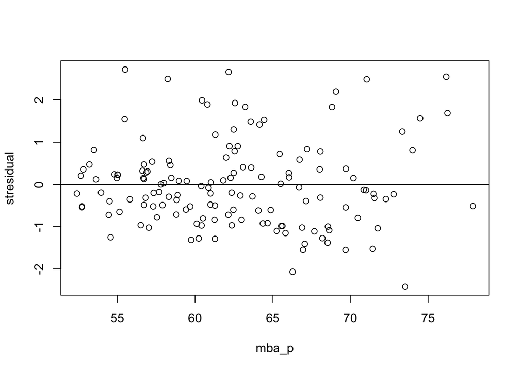

```r
#Standardizing the residuals for observing if the regression model is a good fit..
stresidual <- rstandard(model_salary)

#Plot of standardized regression vs predictor - mba_p
plot(mba_p,stresidual)
abline(0,0)
```

```r
#Analysis: Although standardized residual plot is fairly random, residuals are big and vary widely.
```

*Q. Can the salaries be predicted based on the related variables?*

It’s a weak model, as the predictors are not able to explain the variation in the response variable.

*Q. How can this student cohort be categorized based on their distinct standing on different variables in the dataset?*

```r
library(cluster)
library(Rtsne)
```

Approach: The dataset has categorical and continous variables and as such K-means clustering wouldnt work given the algorithm uses euclidean distance, which can be used for numerical variables. So, to find clusters in the given distance, Gower’s distance will be calculated, which applies Manhattan distance to find distance between continuous variables, and calculates Dice coefficient (2a/2a + b + c) for the categorical variables. The algorithm first converts categorical variables into dummy variables and then calculates Dice coefficient.

Here: a - number of dummies 1 for both individuals b - number of dummies 1 for this and 0 for that c - number of dummies 0 for this and 1 for that d - number of dummies 0 for both